# 08_get_freq

## 08_get_freq

#### Question

1. A sinusoidal [pure tone](https://en.wikipedia.org/wiki/Pure_tone) is generated by randomly choosing a frequency ($F$) in the following equation:
   $$y(t) ~=~ \cos(2\pi F t)$$

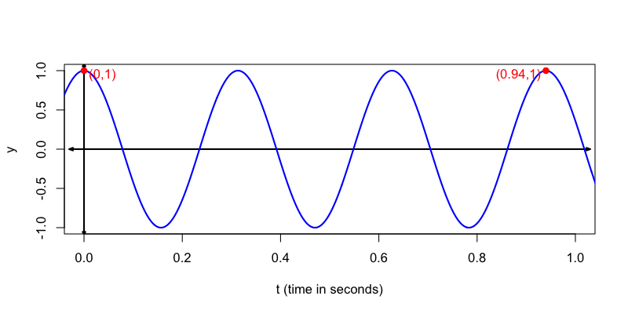

   As shown above, the curve has maximums at both $t=0$ and $t=0.94$. What is the frequency in [Hz](https://en.wikipedia.org/wiki/Hertz)? The tolerance is $\pm 0.01$ Hz.

#### Question

2. A sinusoidal [pure tone](https://en.wikipedia.org/wiki/Pure_tone) is generated by randomly choosing a frequency ($F$) in the following equation:
   $$y(t) ~=~ \cos(2\pi F t)$$

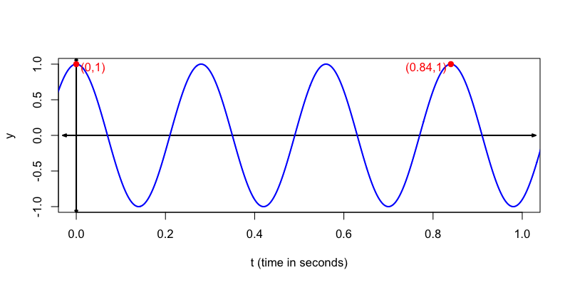

   As shown above, the curve has maximums at both $t=0$ and $t=0.84$. What is the frequency in [Hz](https://en.wikipedia.org/wiki/Hertz)? The tolerance is $\pm 0.01$ Hz.

#### Question

3. A sinusoidal [pure tone](https://en.wikipedia.org/wiki/Pure_tone) is generated by randomly choosing a frequency ($F$) in the following equation:
   $$y(t) ~=~ \cos(2\pi F t)$$

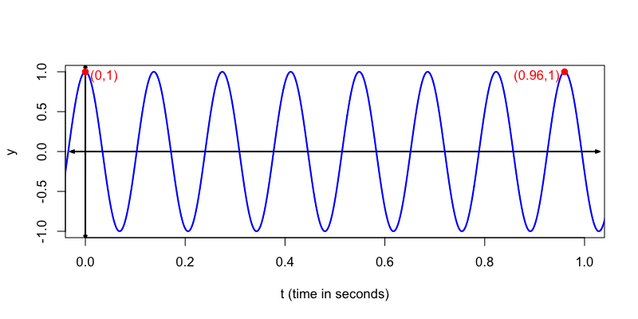

   As shown above, the curve has maximums at both $t=0$ and $t=0.96$. What is the frequency in [Hz](https://en.wikipedia.org/wiki/Hertz)? The tolerance is $\pm 0.01$ Hz.

#### Question

4. A sinusoidal [pure tone](https://en.wikipedia.org/wiki/Pure_tone) is generated by randomly choosing a frequency ($F$) in the following equation:
   $$y(t) ~=~ \cos(2\pi F t)$$

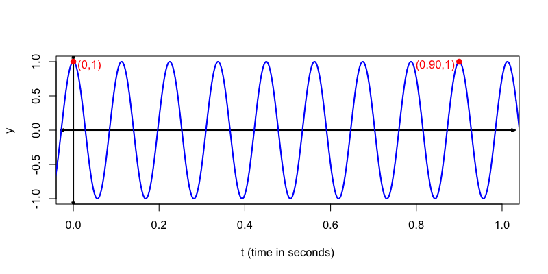

   As shown above, the curve has maximums at both $t=0$ and $t=0.9$. What is the frequency in [Hz](https://en.wikipedia.org/wiki/Hertz)? The tolerance is $\pm 0.01$ Hz.

#### Question

5. A sinusoidal [pure tone](https://en.wikipedia.org/wiki/Pure_tone) is generated by randomly choosing a frequency ($F$) in the following equation:
   $$y(t) ~=~ \cos(2\pi F t)$$

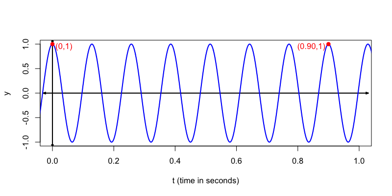

   As shown above, the curve has maximums at both $t=0$ and $t=0.9$. What is the frequency in [Hz](https://en.wikipedia.org/wiki/Hertz)? The tolerance is $\pm 0.01$ Hz.

#### Question

6. A sinusoidal [pure tone](https://en.wikipedia.org/wiki/Pure_tone) is generated by randomly choosing a frequency ($F$) in the following equation:
   $$y(t) ~=~ \cos(2\pi F t)$$

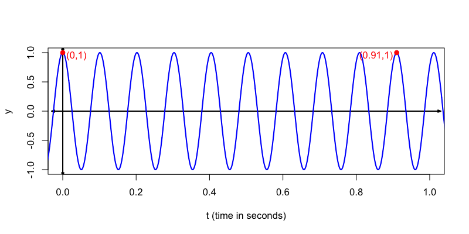

   As shown above, the curve has maximums at both $t=0$ and $t=0.91$. What is the frequency in [Hz](https://en.wikipedia.org/wiki/Hertz)? The tolerance is $\pm 0.01$ Hz.

#### Question

7. A sinusoidal [pure tone](https://en.wikipedia.org/wiki/Pure_tone) is generated by randomly choosing a frequency ($F$) in the following equation:
   $$y(t) ~=~ \cos(2\pi F t)$$

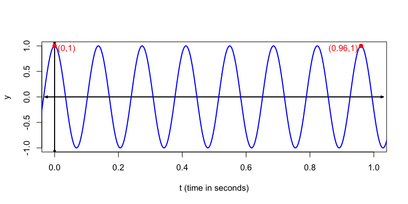

   As shown above, the curve has maximums at both $t=0$ and $t=0.96$. What is the frequency in [Hz](https://en.wikipedia.org/wiki/Hertz)? The tolerance is $\pm 0.01$ Hz.

#### Question

8. A sinusoidal [pure tone](https://en.wikipedia.org/wiki/Pure_tone) is generated by randomly choosing a frequency ($F$) in the following equation:
   $$y(t) ~=~ \cos(2\pi F t)$$

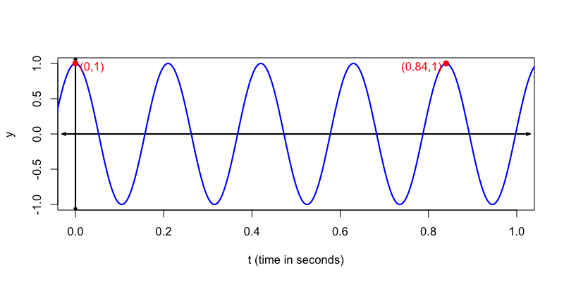

   As shown above, the curve has maximums at both $t=0$ and $t=0.84$. What is the frequency in [Hz](https://en.wikipedia.org/wiki/Hertz)? The tolerance is $\pm 0.01$ Hz.